# Tidy Data

# Longer example: Dealing with untidy data using pipe function and both gather() and spread() to pick apart a messy code string used in the data input

## Your Turn 5

The *who* dataset is very messy... the names of column 5 to 60 are a string of information about TB cases, where for example: sp = pulmonary TB, smear positive; sn = pulmonary TB, smear negative etc. The character after this represents if the individual is male (m) or female (f). A code follows this which represents their age where 014 = age group 0 to 14 years; 1524 = age group 15 to 24 years etc.

| country | iso2 | iso3 | year | new_sp_m014 | new_sp_m1524 | new_sp_m2534 | new_sp_m3544 | new_sp_m4554 | new_sp_m5564 | new_sp_m65 | new_sp_f014 | new_sp_f1524 | new_sp_f2534 | new_sp_f3544 | new_sp_f4554 | new_sp_f5564 | new_sp_f65 | new_sn_m014 | new_sn_m1524 | new_sn_m2534 | new_sn_m3544 | new_sn_m4554 | new_sn_m5564 | new_sn_m65 | new_sn_f014 | new_sn_f1524 | new_sn_f2534 | new_sn_f3544 | new_sn_f4554 | … |
| --- | --- | --- | --- | --- | --- | --- | --- | --- | --- | --- | --- | --- | --- | --- | --- | --- | --- | --- | --- | --- | --- | --- | --- | --- | --- | --- | --- | --- | --- | --- |
| Afghanistan | AF | AFG | 1980 | NA | NA | NA | NA | NA | NA | NA | NA | NA | NA | NA | NA | NA | NA | NA | NA | NA | NA | NA | NA | NA | NA | NA | NA | NA | NA | … |
| Afghanistan | AF | AFG | 1981 | NA | NA | NA | NA | NA | NA | NA | NA | NA | NA | NA | NA | NA | NA | NA | NA | NA | NA | NA | NA | NA | NA | NA | NA | NA | NA | … |
| Afghanistan | AF | AFG | 1982 | NA | NA | NA | NA | NA | NA | NA | NA | NA | NA | NA | NA | NA | NA | NA | NA | NA | NA | NA | NA | NA | NA | NA | NA | NA | NA | … |
| Afghanistan | AF | AFG | 1983 | NA | NA | NA | NA | NA | NA | NA | NA | NA | NA | NA | NA | NA | NA | NA | NA | NA | NA | NA | NA | NA | NA | NA | NA | NA | NA | … |
| Afghanistan | AF | AFG | 1984 | NA | NA | NA | NA | NA | NA | NA | NA | NA | NA | NA | NA | NA | NA | NA | NA | NA | NA | NA | NA | NA | NA | NA | NA | NA | NA | … |
| Afghanistan | AF | AFG | 1985 | NA | NA | NA | NA | NA | NA | NA | NA | NA | NA | NA | NA | NA | NA | NA | NA | NA | NA | NA | NA | NA | NA | NA | NA | NA | NA | … |

This information would be simpler to analyse if it were in the long format with the information held in the column code as a single column.

Here we: Gather the 5th through 60th columns of `who` into a key column: value column pair named **codes** and **n**. Then select just the `county`, `year`, `codes` and `n` variables.

```r
who %>% # the data we want to manipulate
 gather("codes", "n", 5:60) %>% # use gather function and specify our columns that we want to manipulate
 select(-iso2, -iso3) # this removes columns iso2 and iso3 to give us the "neater" dataset
```

| country | year | codes | n |
| --- | --- | --- | --- |
| Afghanistan | 1980 | new_sp_m014 | NA |
| Afghanistan | 1981 | new_sp_m014 | NA |
| Afghanistan | 1982 | new_sp_m014 | NA |
| Afghanistan | 1983 | new_sp_m014 | NA |
| Afghanistan | 1984 | new_sp_m014 | NA |
| Afghanistan | 1985 | new_sp_m014 | NA |
| Afghanistan | 1986 | new_sp_m014 | NA |
| Afghanistan | 1987 | new_sp_m014 | NA |
| Afghanistan | 1988 | new_sp_m014 | NA |
| Afghanistan | 1989 | new_sp_m014 | NA |

[output cut: 990 more lines]

## Your Turn 6

We can now Separate the *codes* column into the individual pieces of information that we want. e.g. seperate out the information in the code about sex and age into seperate column of **sex** and **age**.

We do this using seperate() specifying that we need to split the *codes* column into three new columns called "new", "type", "sexage". We can do this using the underscore "_" to identify the seperate parts of the code.

Note that there are 3 parts to the code: "new", "type of TB such as "sp"", and the "sex & age". In this case we shall call the sex & age group "sexage" for now as they are not seperated by a "_"

```r
who %>%
 gather("codes", "n", 5:60) %>%
 select(-iso2, -iso3) %>%
separate(codes, into = c("new", "type", "sexage"), sep = "_") %>%
 select(-new) #this removes the "new" column which does not hold any data of interest for us in this example
```

| country | year | type | sexage | n |
| --- | --- | --- | --- | --- |
| Afghanistan | 1980 | sp | m014 | NA |
| Afghanistan | 1981 | sp | m014 | NA |
| Afghanistan | 1982 | sp | m014 | NA |
| Afghanistan | 1983 | sp | m014 | NA |
| Afghanistan | 1984 | sp | m014 | NA |
| Afghanistan | 1985 | sp | m014 | NA |
| Afghanistan | 1986 | sp | m014 | NA |
| Afghanistan | 1987 | sp | m014 | NA |
| Afghanistan | 1988 | sp | m014 | NA |
| Afghanistan | 1989 | sp | m014 | NA |

[output cut: 990 more lines]

We can now split the column *sexage* into sex and age by specify the number of *characters* to split by. In this case, we want it to split after ONE character (the m/f character) and put the remaining into a seperate age column.

```r
who %>%
 gather("codes", "n", 5:60) %>%
  select(-iso2, -iso3) %>%
  separate(codes, into = c("new", "type", "sexage"), sep = "_") %>%
   select(-new) %>%
  separate(sexage, into = c("sex", "age"), sep = 1) %>%
  drop_na(n) # we can use drop_na to remove nas from the data if desired
```

| country | year | type | sex | age | n |
| --- | --- | --- | --- | --- | --- |
| Afghanistan | 1997 | sp | m | 014 | 0 |
| Afghanistan | 1998 | sp | m | 014 | 30 |
| Afghanistan | 1999 | sp | m | 014 | 8 |
| Afghanistan | 2000 | sp | m | 014 | 52 |
| Afghanistan | 2001 | sp | m | 014 | 129 |
| Afghanistan | 2002 | sp | m | 014 | 90 |
| Afghanistan | 2003 | sp | m | 014 | 127 |
| Afghanistan | 2004 | sp | m | 014 | 139 |
| Afghanistan | 2005 | sp | m | 014 | 151 |
| Afghanistan | 2006 | sp | m | 014 | 193 |

[output cut: 990 more lines]

Sometimes we might want to combine the cells in two seperate columns (or more) into one column to create a single column code. We can do this using unite().

Lets do this now by re-combining the sex and age to get the "sexage" column back.

[output not shown]

[output cut: 990 more lines]

## Your Turn 7

**babynames** contains data of Number of children by year and gender

```r
head(babynames)
```

| year | sex | name | n | prop |
| --- | --- | --- | --- | --- |
| 1880 | F | Mary | 7065 | 0.07238359 |
| 1880 | F | Anna | 2604 | 0.02667896 |
| 1880 | F | Emma | 2003 | 0.02052149 |
| 1880 | F | Elizabeth | 1939 | 0.01986579 |
| 1880 | F | Minnie | 1746 | 0.01788843 |
| 1880 | F | Margaret | 1578 | 0.01616720 |

Can we calculate the ratio of boys to girls by year?

First step summaries the number of males and females born by year:

```r
babynames %>%
  group_by(year, sex) %>%
  summarise(n = sum(n))
```

| year | sex | n |
| --- | --- | --- |
| 1880 | F | 90993 |
| 1880 | M | 110491 |
| 1881 | F | 91953 |
| 1881 | M | 100743 |
| 1882 | F | 107847 |
| 1882 | M | 113686 |
| 1883 | F | 112319 |
| 1883 | M | 104627 |
| 1884 | F | 129020 |
| 1884 | M | 114442 |

[output cut: 266 more lines]

Then use spread to convert long to wide by gender.

```r
babynames %>%
 group_by(year, sex) %>%
 summarise(n = sum(n)) %>%
 spread(sex, n) # spread column "sex" into M and F columns and call the new column with the cell values "n" for count
```

| year | F | M |
| --- | --- | --- |
| 1880 | 90993 | 110491 |
| 1881 | 91953 | 100743 |
| 1882 | 107847 | 113686 |
| 1883 | 112319 | 104627 |
| 1884 | 129020 | 114442 |
| 1885 | 133055 | 107799 |
| 1886 | 144533 | 110784 |
| 1887 | 145981 | 101413 |
| 1888 | 178622 | 120851 |
| 1889 | 178366 | 110580 |

[output cut: 128 more lines]

From here, we can now calculate the percent of male children by year by using **mutate()**. This preserves all the current columns and creates a new column, in this case called "percent_male", which uses the data from columns M and F to calculate the percentage.

```r
babynames %>%
 group_by(year, sex) %>%
 summarise(n = sum(n)) %>%
 spread(sex, n) %>%
  mutate(percent_male = M / (M + F) * 100)
```

| year | F | M | percent_male |
| --- | --- | --- | --- |
| 1880 | 90993 | 110491 | 54.83860 |
| 1881 | 91953 | 100743 | 52.28079 |
| 1882 | 107847 | 113686 | 51.31786 |
| 1883 | 112319 | 104627 | 48.22721 |
| 1884 | 129020 | 114442 | 47.00610 |
| 1885 | 133055 | 107799 | 44.75699 |
| 1886 | 144533 | 110784 | 43.39077 |
| 1887 | 145981 | 101413 | 40.99251 |
| 1888 | 178622 | 120851 | 40.35456 |
| 1889 | 178366 | 110580 | 38.27013 |

[output cut: 128 more lines]

Repeat but for percentage of females.

```r
babynames %>%
 group_by(year, sex) %>%
 summarise(n = sum(n)) %>%
 spread(sex, n) %>%
  mutate(percent_female = F / (M + F) * 100)
```

| year | F | M | percent_female |
| --- | --- | --- | --- |
| 1880 | 90993 | 110491 | 45.16140 |
| 1881 | 91953 | 100743 | 47.71921 |
| 1882 | 107847 | 113686 | 48.68214 |
| 1883 | 112319 | 104627 | 51.77279 |
| 1884 | 129020 | 114442 | 52.99390 |
| 1885 | 133055 | 107799 | 55.24301 |
| 1886 | 144533 | 110784 | 56.60923 |
| 1887 | 145981 | 101413 | 59.00749 |
| 1888 | 178622 | 120851 | 59.64544 |
| 1889 | 178366 | 110580 | 61.72987 |

[output cut: 128 more lines]

Lets now plot this as the percent over time for boys.

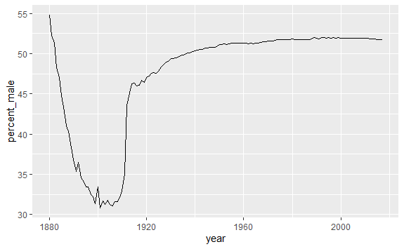

```r
babynames %>%
 group_by(year, sex) %>%
 summarise(n = sum(n)) %>%
 spread(sex, n) %>%
  mutate(percent_male = M / (M + F) * 100) %>%
 ggplot(aes(year, percent_male)) +
  geom_line()
```

Lets make the graph a bit more fancy!

Display both male and female, add labels and have a white background.

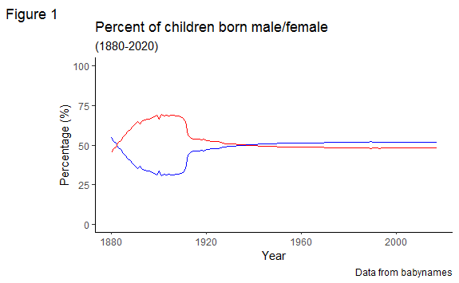

```r
babynames %>%
 group_by(year, sex) %>%
 summarise(n = sum(n)) %>%
 spread(sex, n) %>%
  mutate(percent_male = M / (M + F) * 100) %>%
  mutate(percent_female = F / (M + F) * 100) %>%
 ggplot(aes(year, percent_male)) +
  geom_line(aes(year, percent_male), colour = "blue") +
   geom_line(aes(year, percent_female), colour = "red") +
    labs(
    title = "Percent of children born male/female",
    subtitle = "(1880-2020)",
    caption = "Data from babynames",
    tag = "Figure 1",
    x = "Year",
    y = "Percentage (%)",
    colour = "Sex"
  ) +
  ylim(0, 100) +
  theme_classic()
```

```r
# unique(as.factor(babynames$name))
# 97,310 baby names!
# There are 1.8M rows of data!
```

# Recap

Move values into column names with spread() - image smearing the column across the screen!

Move column names into values with gather() - imagine pulling the columns down

Split a column with separate()

Unite columns with unite()

# Take Aways

Data comes in many formats but R prefers just one: *tidy data*.

A data set is tidy if and only if:

1. Every variable is in its own column
2. Every observation is in its own row
3. Every value is in its own cell (which follows from the above)

What is a variable and an observation may depend on your immediate goal.